# STAT 3202: Group Project I

Charles Doan, Yiting Chen, Hannah Mazzei, Jaima Schulte

OSU, Spring Semester: 02/26/2019

## Introduction

In this project we will analyze data gathered by the World Health Organization containing measures of average alcohol consumption by country among those 15 and older in the year 2010. The data consists of averages categorized by beverage type: beer (typically 5% alcohol by volume), spirits (typically 30-40% alcohol by volume), and wine (typically 13.5% alcohol by volume). There are values for 193 countries in the 3 categories.

Alcohol consumption is likely correlated with other variables such as life expectancy, general health, incarceration rates, and educational achievement. This implies that useful insights might be gained by studying how alcohol consumption varies from country to country.

Therefore, the goal of this analysis is to find approximating distributions for the average consumption of the various beverage types, and then present intuitive visualizations for the results. We will use our knowledge of parameter estimation methods to tailor our chosen distributions to the data as closely as possible. Among the visualizations, we will include world map diagrams representing average consumption rates for each of the measured alcohol categories across countries.

A complete data dictionary explaining each of the variables is available in the Appendix.

## Methods

### Data

In the Appendix one may observe that the data has both categorical and quantitative variables; “country” is the only categorical variable and “beer_servings”, “spirit_servings”, and “wine_servings” are each numerical. Each row shows the different levels of consumption for each country. Prior to analysis we added a fourth category for total consumption, which is a summation of the three numerical variables.

The data gathered by the WHO was initially measured in average liters of pure alcohol per capita. However, to make the presentation more intuitive these measurements were transformed into standard servings as a function of the measured liters and the average alcohol content for each respective category.

In order to predict the distribution of our sample, we plotted histograms and box plots for each of the beverages, as well as a table of summary statistics.

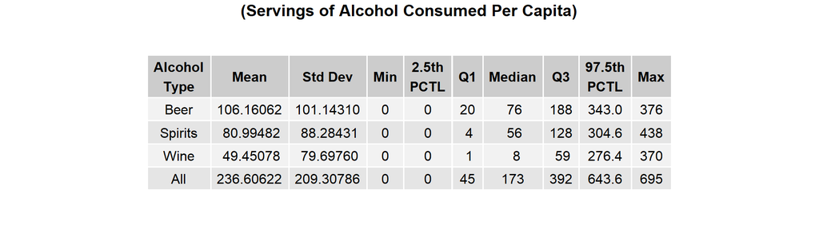

Some interesting trends to note in this table are that the mean is always significantly higher than the median in all 4 cases, indicating that our data is skewed. The size of the differences imply that a relatively small number of the data points have a large impact on the means. Additionally, the standard deviations are very high relative to their respective means, implying thin spreads over large ranges. Below we plot the data to give a more intuitive sense of this variation.

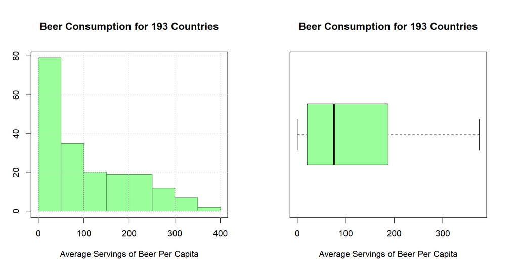

Here we have the graphical summaries for average beer consumption. The histogram and box plot indicate that this sample is strongly skewed right, however there are no apparent outliers in the data. We observe similar trends in the data for the other alcohol categories, as shown below.

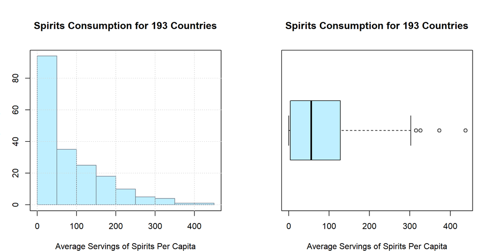

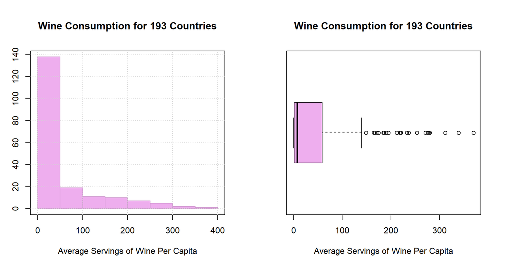

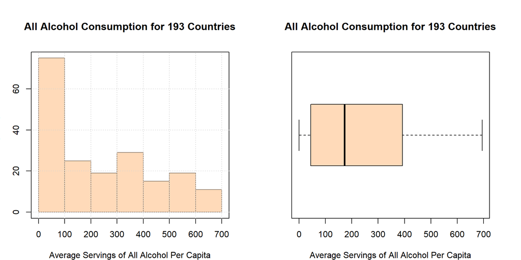

The graphical and numerical summaries for both spirits and wine consumption show that these samples are are even more dramatically right-skewed than the beer sample. Total consumption seems to show a fairly smooth merging of the three categories. Because each sample is significantly skewed, using a symmetric distsribution such as the normal to estimate a model would likely result in a poor fit of the data. Additionally, we are not looking to analyze proportions in this data, therefore a beta distribution would make little sense. Instead, we will assume gamma and exponential distributions in order to model our data.

### Models

While it is not possible to find analytic solutions for the Maximum Likelihood estimators of a Gamma distribution, we can use the Method of Moments to yield the following estimators for $\tilde{\alpha}$ (the shape) and $\tilde{\beta}$ (the scale):

$$\tilde{\alpha} = \frac{\bar{x}^2}{\overline{x^2} - \bar{x}^2}$$

$$\tilde{\beta} = \frac{\overline{x^2} - \bar{x}^2}{\bar{x}}$$

where $\bar{x}$ is the sample mean:

$$\bar{x} = \frac{1}{n}\sum_{i = 1}^{n}x_i$$
and $\overline{x^2}$ is the second sample moment:
$$\overline{x^2} = \frac{1}{n}\sum_{i = 1}^{n}x_i^2$$
Using these estimators, we can estimate values for ${\alpha}$ and ${\beta}$ for each beverage type to construct a gamma curve that will fit the data.

Similarly, we may estimate $\tilde{\beta}$ (the scale parameter) of the exponential distribution using the Method of Moments as follows:
$$\tilde{\beta} = \bar{x}$$

In order to generate the world maps, we’ll make use of the `rworldmap` package. We will produce separate maps for beer consumption, spirit consumption, wine consumption, and total alcohol consumption in order to provide a big picture perspective on average alcohol consumption around the world.

## Results

Starting with the distribution for beer consumption using the equations listed above, we calculate $\tilde{\alpha}$ = 1.11 and $\tilde{\beta}$ = 95.9 for our gamma estimators, and $\tilde{\lambda}$ = $1/\tilde{\beta}$ = 0.00942 for our exponential estimator. Similarly we can estimate the parameters for each of the other categories of average consumption, enabling us to produce the following graphs:

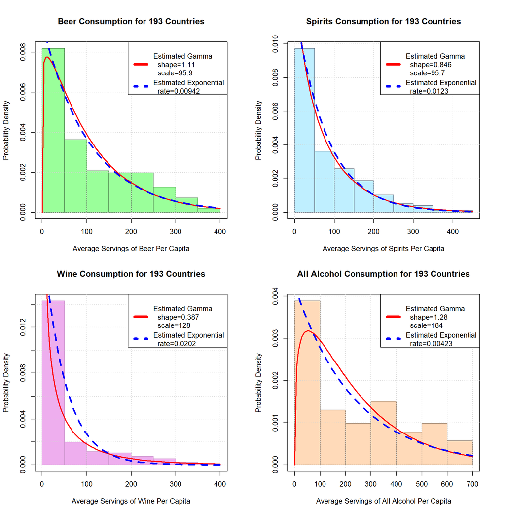

While these graphs provide some insight as to how our estimates look in comparison to the actual data, simply looking at them doesn’t necessarily indicate which distributions are a better fit for which beverages. Therefore, below we produce qq-plots for each category to provide a better sense of the fit.

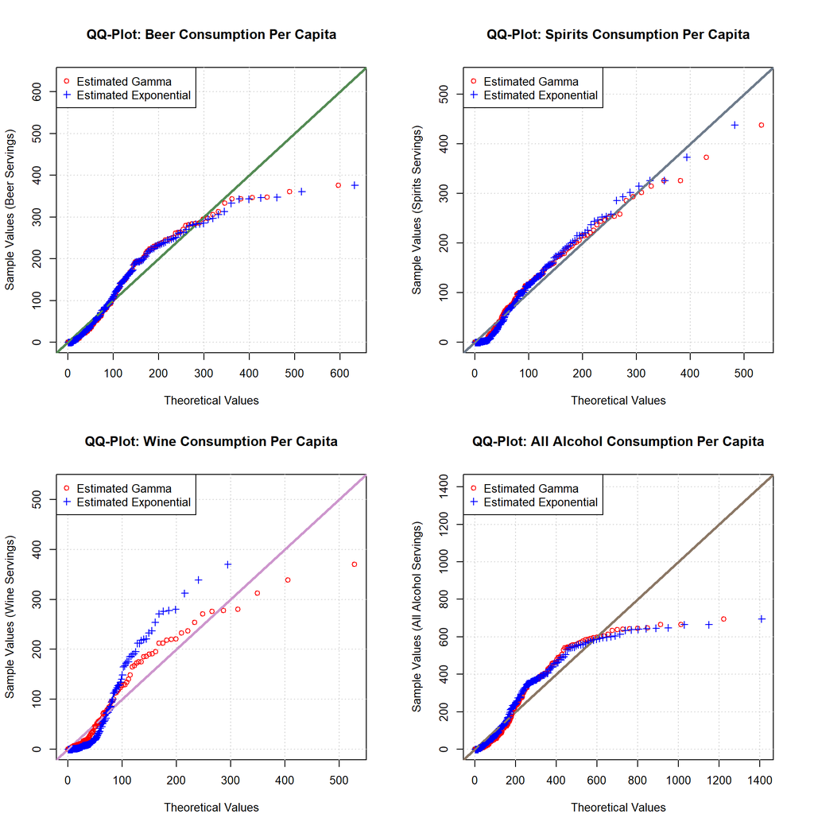

Observing the QQ-Plots, it is apparent that the Gamma and Exponential distributions produce similar fits to the data. In the case of average beer consumption, the theoretical values fit reasonably well up until the tail of the distribution, at which point they begin to diverge. This is the case for average spirits consumption as well, but the divergence is less dramatic, showing a better fit throughout.

It is not clear that one distribution fits the data better than the other in either case. Unfortunately, in the case of average wine consumption neither distribution appears to fit the data very well. However, being the more flexible of the two, the Gamma distribution is better able to accomodate the strange ‘L’ shape of the data, and produces a better fit.

In the case of total alcohol consumption, the estimated values fit as one might expect from an average of the three categories, showing the overall trend: Decent estimation between 0 servings and the mean, followed by slightly biased estimation above the mean until the divergence begins to incrase rapidly in the tail. Neither distribution appears to be significantly better in fit than the other.

World Map Representation

Lastly, to get a sense for how alcohol consumption is distributed globally, we have provided color-coded maps showing the average consumption for each country. Regions colored in black represent countries for which we have no data.

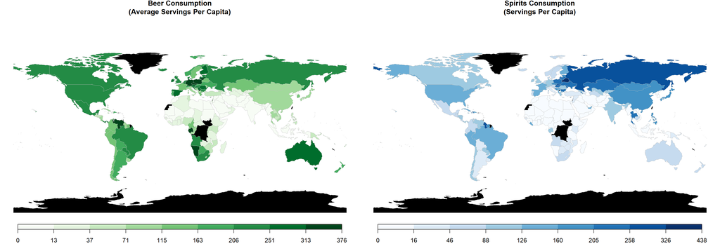

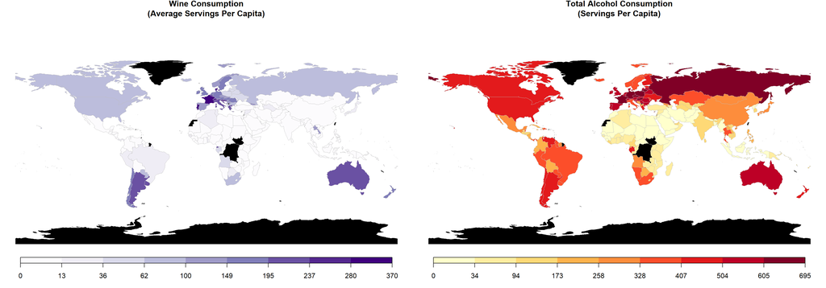

## Appendix

The variables contained in the data set are:

`country`, the name of the country  
`beer_servings`, the number of beer servings per capita  
`spirit_servings`, the number of spirit servings per capita  
`wine_servings`, the number of wine servings per capita